# FinalProject

Raj Patel

5/3/2021

```r
library(tidyverse)
library(here)
library(rvest)
library(janitor)
library(gtools)
library(lubridate)
library(gganimate)
library(gifski)
knitr::opts_chunk$set(echo = FALSE)
```

## Basketball Data

To begin, my first dataset I am working with involves the National Basketball Association Rookie Data. Specifically, it includes 2019-2020 Rookies/2018-2019 Rookies and their respective stats for their Rookie season. This data can be found on the websites: “https://www.basketball-reference.com/leagues/NBA_2020_rookies-season-stats.html” “https://www.basketball-reference.com/leagues/NBA_2019_rookies-season-stats.html” “https://www.basketball-reference.com/draft/NBA_2019.html” “https://www.basketball-reference.com/draft/NBA_2018.html”

As such, to begin this project, I am going to first have to scrape the data from the webpage. However, Some websites request that no bots access the page. Thus I will first have to honor that request:

I also will be including several url’s for 2020 Rookies and 2019 Rookies that will be needed later as well.

```r
url_2020 <- "https://www.basketball-reference.com/leagues/NBA_2020_rookies-season-stats.html"
url_2019 <- "https://www.basketball-reference.com/leagues/NBA_2019_rookies-season-stats.html"

url_2020_draft <- "https://www.basketball-reference.com/draft/NBA_2019.html"
url_2019_draft <- "https://www.basketball-reference.com/draft/NBA_2018.html"

robotstxt::paths_allowed(url_2020)
robotstxt::paths_allowed(url_2020_draft)
robotstxt::paths_allowed(url_2019)
robotstxt::paths_allowed(url_2019_draft)
```

[output not shown]

## Reading in the Data

We can proceed and scrape the NBA data from the page. However, when scraping the data initally in, I noticed that the header Names were not scraping in how I wanted it. The names that I wanted was read as the first row in the data. In order to fix this, I used neat function “row_to_names” from the Janitor package to convert that firt row to be the column names for the Data.

In addition, there were a couple rows that did not include any player. Thus, included some code to get rid of those as well!

This was done for both 2020 NBA rookies and 2019 NBA rookies

I did the same to the data from the other page which including draft information for the players!

## More cleaning

In addition, all the variables are character variables which we do not need. Since we are focused on looking at the numerical data, we need to convert those into the right type of variable!

Here are the first five rows from each dataset for 2020 Rookies and 2019 Rookies!

```
## # A tibble: 5 x 28
##      Rk Player Debut   Age   Yrs     G    Mp    Fg   Fga `3p Makes`
##   <dbl> <chr>  <chr> <dbl> <dbl> <dbl> <dbl> <dbl> <dbl>      <dbl>
## 1     1 Kyle ~ Aug ~    23     1     2    13     1     2          0
## 2     2 Nicke~ Oct ~    21     1    47   591    98   266         46
## 3     3 RJ Ba~ Oct ~    19     1    56  1704   292   727         63
## 4     4 Dariu~ Oct ~    19     1    61  1130   125   317         49
## 5     5 Goga ~ Oct ~    20     1    54   471    70   150          8
## # ... with 18 more variables: `3p attempts` <dbl>, Ft <dbl>, Fta <dbl>,
## #   Orb <dbl>, Trb <dbl>, Ast <dbl>, Stl <dbl>, Blk <dbl>, Tov <dbl>, Pf <dbl>,
## #   Pts <dbl>, FgPercent <dbl>, X3PPercent <dbl>, FtPercent <dbl>,
## #   Average_minutes <dbl>, Average_pts <dbl>, Average_rebounds <dbl>,
## #   Average_assists <dbl>
```

```
## # A tibble: 5 x 28
##      Rk Player Debut   Age   Yrs     G    Mp    Fg   Fga `3p Makes`
##   <dbl> <chr>  <chr> <dbl> <dbl> <dbl> <dbl> <dbl> <dbl>      <dbl>
## 1     1 Jayle~ Oct ~    22     1    34   428    38   110         25
## 2     2 Deng ~ Jan ~    21     1    19   194    11    36          6
## 3     3 DeVau~ Oct ~    25     1     7    22     3    10          0
## 4     4 Rawle~ Dec ~    21     1    10   120    13    39          3
## 5     5 Grays~ Oct ~    23     1    38   416    67   178         32
## # ... with 18 more variables: `3p attempts` <dbl>, Ft <dbl>, Fta <dbl>,
## #   Orb <dbl>, Trb <dbl>, Ast <dbl>, Stl <dbl>, Blk <dbl>, Tov <dbl>, Pf <dbl>,
## #   Pts <dbl>, FgPercent <dbl>, X3PPercent <dbl>, FtPercent <dbl>,
## #   Average_minutes <dbl>, Average_pts <dbl>, Average_rebounds <dbl>,
## #   Average_assists <dbl>
```

Similarly, I cleaned up some of the names for the Draft data but not as much as I did with the main data. This is because I am only concerned with some of the column names from this Draft data as I want those columns in the main data in a future code chunk using ‘left join’.

Here are the first five rows of the Nba 2020 and Nba 2019 Drafted Rookies:

```
## # A tibble: 5 x 22
##      Rk    Pk Tm    Player College   Yrs     G    Mp   Pts   Trb   Ast FgPercent
##   <dbl> <dbl> <chr> <chr>  <chr>   <dbl> <dbl> <dbl> <dbl> <dbl> <dbl>     <dbl>
## 1     1     1 NOP   Zion ~ Duke        2    85  2694  2187   591   276     0.604
## 2     2     2 MEM   Ja Mo~ Murray~     3   187  6016  3961   836  1337     0.474
## 3     3     3 NYK   RJ Ba~ Duke        3   198  6632  3469  1101   568     0.418
## 4     4     4 LAL   De'An~ Virgin~     3   139  4273  1831   572   224     0.434
## 5     5     5 CLE   Dariu~ Vander~     3   181  6044  3142   464  1141     0.443
## # ... with 10 more variables: X3PPercent <dbl>, FtPercent <dbl>, Mp_2 <dbl>,
## #   Pts_2 <dbl>, Trb_2 <dbl>, Ast_2 <dbl>, Ws <dbl>, Ws48 <dbl>, Bpm <dbl>,
## #   Vorp <dbl>
```

```
## # A tibble: 5 x 22
##      Rk    Pk Tm    Player College   Yrs     G    Mp   Pts   Trb   Ast FgPercent
##   <dbl> <dbl> <chr> <chr>  <chr>   <dbl> <dbl> <dbl> <dbl> <dbl> <dbl>     <dbl>
## 1     1     1 PHO   Deand~ "Arizo~     4   236  7247  3843  2485   380     0.599
## 2     2     2 SAC   Marvi~ "Duke"      4   166  4159  2256  1224   151     0.501
## 3     3     3 ATL   Luka ~ ""          4   264  8928  6962  2256  2102     0.457
## 4     4     4 MEM   Jaren~ "Michi~     4   204  5521  3218  1050   240     0.453
## 5     5     5 DAL   Trae ~ "Oklah~     4   280  9400  7076  1085  2544     0.44
## # ... with 10 more variables: X3PPercent <dbl>, FtPercent <dbl>, Mp_2 <dbl>,
## #   Pts_2 <dbl>, Trb_2 <dbl>, Ast_2 <dbl>, Ws <dbl>, Ws48 <dbl>, Bpm <dbl>,
## #   Vorp <dbl>
```

## Date

Now that we got the numeric data covered, I noticed that the Debut variable was a character variable despite having a Date within it as well as the debut game that the rookie played in. Therefore, I feel that the best approach is to split the Debut variable into two unique variables: “Date_of_Debut” and “Debut_Opponent”. With this, the “Date_of_Debut” column can be transferred into a Date variable whereas the “Debut_Opponent” variable can remain a character variable.

In addition, I noticed that the first team listed in the “Debut” variable was the team that drafted the rookie. Therefore, I want to create another variable called “Team” to designate what team the rookie plays for! I will tackle this first and also relocate that column next to the Player column and then split the “Debut” variable after!

```r
nba_data_2020 <- nba_data_2020 %>%
  mutate(Team = str_extract(Debut,"\\s[A-z]{3}\\s") %>%
           str_trim()) %>%
  relocate(Team, .before = Debut) %>%
  mutate(Date_of_Debut = str_split(Debut, "(\\s[A-z]{3}\\s){1}") %>%
           map_chr(1) %>%
           str_replace_all("\\,","") %>%
           str_replace("\\'","20") %>%
           mdy()) %>%
  relocate(Date_of_Debut, .before = Age) %>%
  mutate(Debut_Opponent = str_extract(Debut, "[A-z]{3}$") %>%
           str_trim()) %>%
  relocate(Debut_Opponent, .before = Age) %>%
  select(-c(Debut,Rk))

nba_data_2019 <- nba_data_2019 %>%
  mutate(Team = str_extract(Debut,"\\s[A-z]{3}\\s") %>%
           str_trim()) %>%
  relocate(Team, .before = Debut) %>%
  mutate(Date_of_Debut = str_split(Debut, "(\\s[A-z]{3}\\s){1}") %>%
           map_chr(1) %>%
           str_replace_all("\\,","") %>%
           str_replace("\\'","20") %>%
           mdy()) %>%
  relocate(Date_of_Debut, .before = Age) %>%
  mutate(Debut_Opponent = str_extract(Debut, "[A-z]{3}$") %>%
           str_trim()) %>%
  relocate(Debut_Opponent, .before = Age) %>%
  select(-c(Debut,Rk))
```

Now the Data looks much better!

## Joining Data

I have the data cleaned but I do want some more information in regards to the player. Mainly, I want the college and the draft position of the Rookies that got drafted in the 2019 NBA draft.

Therefore, I am going to create a new DF that includes the Rookie Draft positions of those who got drafted and save it under ‘nba_drafted_rookies’ using a left join.

Note that there will not be 60 players in the DF since some players that were drafted did not play in the 2019-2020 NBA Season or 2018-2019 Season. I also only selected several variables as this DF will be used for plotting!

Here, I have the first five rows of the joined date for 2020 Rookies and 2019 Rookies:

```
## # A tibble: 5 x 11
##   Player Team  College   Age     G    Pk   Pts Average_pts Average_rebounds
##   <chr>  <chr> <chr>   <dbl> <dbl> <dbl> <dbl>       <dbl>            <dbl>
## 1 Zion ~ NOP   Duke       19    24     1   540        22.5              6.3
## 2 Ja Mo~ MEM   Murray~    20    67     2  1193        17.8              3.9
## 3 RJ Ba~ NYK   Duke       19    56     3   803        14.3              5
## 4 De'An~ ATL   Virgin~    22    63     4   778        12.3              4.5
## 5 Dariu~ CLE   Vander~    20    59     5   728        12.3              1.9
## # ... with 2 more variables: Average_assists <dbl>, Year <dbl>
```

```
## # A tibble: 5 x 11
##   Player Team  College   Age     G    Pk   Pts Average_pts Average_rebounds
##   <chr>  <chr> <chr>   <dbl> <dbl> <dbl> <dbl>       <dbl>            <dbl>
## 1 Deand~ PHO   "Arizo~    20    71     1  1159        16.3             10.3
## 2 Marvi~ SAC   "Duke"     19    62     2   923        14.9              7.6
## 3 Luka ~ DAL   ""         19    72     3  1526        21.2              7.8
## 4 Jaren~ MEM   "Michi~    19    58     4   798        13.8              4.7
## 5 Trae ~ ATL   "Oklah~    20    81     5  1549        19.1              3.7
## # ... with 2 more variables: Average_assists <dbl>, Year <dbl>
```

## Plot

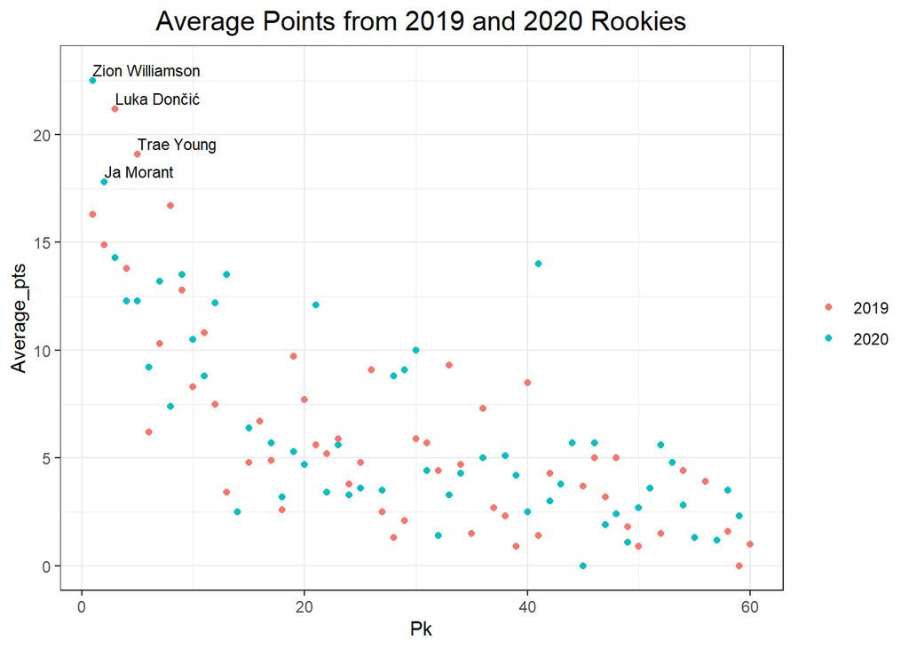

Looking at the plot, seems to be that most of the lottery teams from both years choose the right players to draft. It also seems to be that players drafted later tend to average less points that those drafted earlier which makes sense! However, from the plot, I noticed there’s one player drafted in 2020 that appears to stray away from that trend averaging more than 10 points and drafted later than 40. Let’s find out who that is!

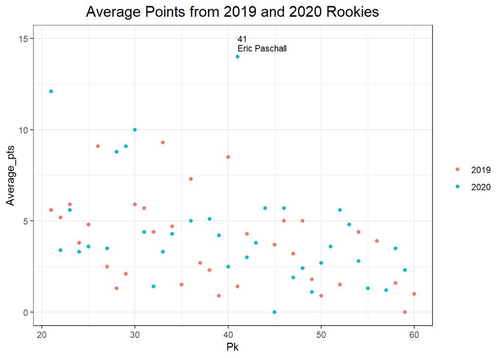

## Plot

Now with the cleaned data, I wanted to see the relationship between the age of the rookie and their averages for 2019 Rookies and 2020 Rookies.

I first only looked at Rookies that played over 10 games and visualized a boxplot differentiated by Class Year.

I then made a Bar chart to visualize the total amount of points scores by Age for the 2020 Rookies and the 2019 Rookies. I wanted to see how both draft classes compared by Age through a graphical representation.

Since some rookies do not play many games, I wanted to observe only rookies that played over 10 games since I felt 10 games out of a 81 game season was an adequate amount.

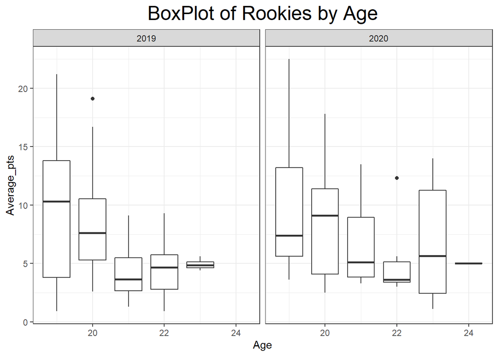

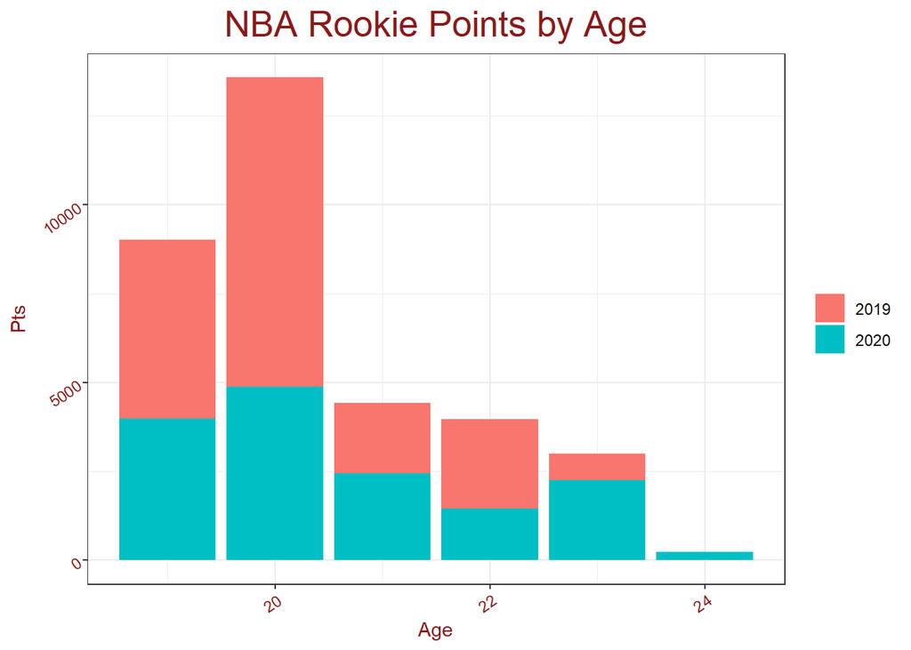

Observing the data, looks like 20 year olds from the draft scored the most points in both the 2019 Class and 2020 Class. In addition, It appears that the 2019 Draft Class scored more in total and that there were no 24 year olds in the 2019 NBA Draft but there was atleast one in the 2020 NBA Draft.

## Football Data

For this data, I am using List of most watch television broadcasts in the US from Wiki: “https://en.wikipedia.org/wiki/List_of_most_watched_television_broadcasts_in_the_United_States#:~:text=Super%20Bowl%20XLIX%20is%20currently,broadcast%20with%20114.4%20million%20viewers”

I am going to first read it in and then check whether bots can access the page

```
##
 en.wikipedia.org
```

```
## [1] TRUE
```

## Clean Data

Since I can access the page with bots, I am going to scrape the data from Wikipedia and clean the data by making some of the variables into the correct type i.e Rank to numeric, Date to Date, etc…

## Roman Numerals

Next, I noticed that many of the broadcasts were Superbowl events. These Superbowls were mainly named with Roman Numerals. I wanted to create a function that converted the Superbowl names into names with numbers instead of Roman Numerals. There was a neat function called ‘roman2int’ from gtools that I used in the function.

I then will use the function on the DF ‘Top_Broadcasts’ and save it!

```r
roman_numeral_to_numbers <- function(x,w){
  x <- x %>%
    mutate(Roman = str_extract(w,"\\s[A-z]{1,}$"),
           Numeric = roman2int(Roman) %>%
             as.character(),
           Name = str_split(w,"\\s[A-z]{1,}$") %>%
             map_chr(1) %>%
             str_trim(),
           Name = case_when(is.na(Numeric) ~ Name,
                                      TRUE ~ str_c(Name,Numeric, sep = " "))) %>%
    select(-c(Numeric,Roman))

}

Top_Broadcasts <- roman_numeral_to_numbers(Top_Broadcasts,Top_Broadcasts$Broadcast)
```

Let’s check if it did what we needed!

```
## # A tibble: 5 x 7
##    Rank Broadcast           Viewers Date       Network  Year Name
##   <dbl> <chr>                 <dbl> <date>     <chr>   <dbl> <chr>
## 1     1 Super Bowl XLIX   114442000 2015-02-01 NBC      2015 Super Bowl 49
## 2     2 Super Bowl XLVIII 112191000 2014-02-02 Fox      2014 Super Bowl 48
## 3     3 Super Bowl 50     111864000 2016-02-07 CBS      2016 Super Bowl 50
## 4     4 Super Bowl XLVI   111346000 2012-02-05 NBC      2012 Super Bowl 46
## 5     5 Super Bowl LI     111319000 2017-02-05 Fox      2017 Super Bowl 51
```

## Animate

Now, I wanted to visualize the top rated broadcasts in a neat sort of way. Specifically, I wanted to animate the plot by going through the years and plotting a point of the highest rated event from that year by its rank. I will save the animation in ‘anim’ and then run the animation with some neat code to make a gif!!!!!

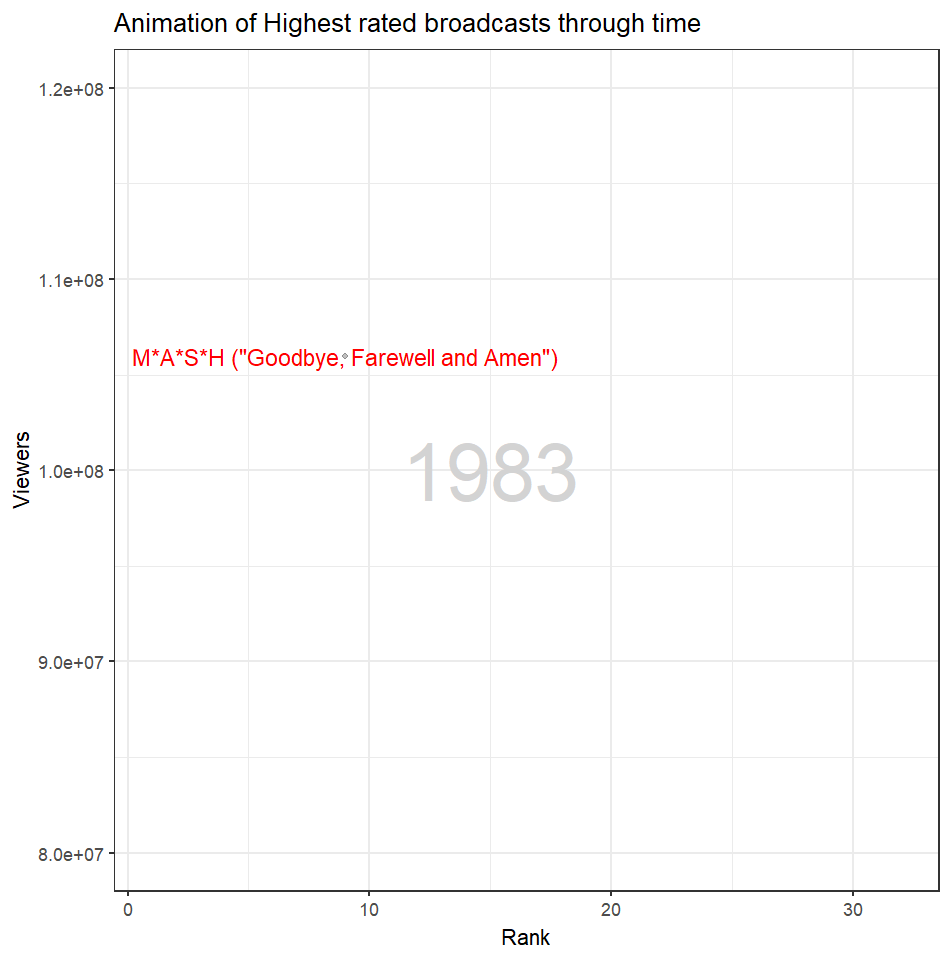

## Write CSV

To conclude, I am going to save the main files ‘nba_drafted_rookies_2019’,‘nba_drafted_rookies_2020’, and ’Top_Broadcasts into csv’s!

```r
nba_drafted_rookies_2019 %>% write_csv(here("nba_drafted_2019"))
nba_drafted_rookies_2020 %>% write_csv(here("nba_drafted_2020"))
Top_Broadcasts %>% write_csv(here("Top_Broadcasts_US"))
```